# QTM 150 Final Project

Prerna Advani

[Link To Dataset](https://github.com/prernaadvani/QTM-150-Final/blob/master/frenchfries.xlsx?raw=true)

Please click on the link above to download the data set and import it into R Studio.

*Note: the reason I did not use the read.csv(https://github.com/prernaadvani/QTM-150-Final/blob/master/frenchfriesresponses.csv?raw=true) code is because I lost formatting when I converted my xlsx file to a csv, and my code did not produce the same results. However, if you would like to view my data as a csv instead of xlsx, it is available [here](https://github.com/prernaadvani/QTM-150-Final/blob/master/frenchfriesresponses.csv?raw=true).*

# **What sauce is the best for eating french fries?**

## Introduction

When I think about why I picked this topic to research, I have to go back to the end of my senior year of high school. It was around April of the year 2017, and I went out with a few of my friends to grab some dinner after a long day at school. Some of us ordered fries with our meal, and one of the people that did so was my friend Emmanuel, who I had known and been friends with for a few years at that point. However, when the food was brought out, I noticed that he mixed mayonnaise and ketchup in a little corner on the side of his plate, dipped his fries in it, and began eating. I couldn’t help but lose a little respect for him that day, and I could never look at him the same after this incident. However, when I got to college, I noticed that he wasn’t the only one to do this. While most people stuck to the traditional fries and ketchup combination, I observed that many people tend to venture out of the typical pairing to dip their fries in various other “sauces”, such as mustard, milkshakes, hot sauce, and mayonnaise. This brings me to last week, when I went out to dinner with my dance team. Within our group of twelve girls, there were only three of us that gravitated towards the ketchup as our dipping sauce for our fries; everyone else combined the fries with a different sauce, one of the most bizarre mixtures in my opinion being hot sauce and mayonnaise. This bring me to the research question, “what sauce is the best for eating french fries?”. I would like to know whether ketchup still remains the most popular sauce for fries, or if it has been replaced by something newer. I would also like to know whether people in general are as appauled by the idea of some of these cominations - such as mustard and mayonnaise, hot sauce and mayonnaise - or if I am the only one who feels so strongly against it.

## Method

I began by listing every sauce that I had seen anyone eat french fries with, and asked some of my friends if they knew of any other mixtures that I had not already listed. Next, to collect my data, I began a google form. The questions included:

1. Name
2. Age
3. Gender
4. What are your thoughts on eating French Fries with each of the following on a scale of 1-5, 1 being ‘never’, and 5 being ‘always’?
- Ketchup
- Mayonnaise
- Ketchup mixed with mayonnaise
- Mustard
- Mustard mixed with mayonnaise
- Ranch dressing
- Chocolate milkshake
- Vanilla milkshake
- Hot sauce
- Mayonnaise and hot sauce
- No sauce

I posted the link to the survey in groupchats for my dance team, sorority, and the Emory class of 2021 groupchat, and received 85 responses.

## Results

### Breakdown of data

*The following tables and charts show the breakdown of my data by gender and by age.*

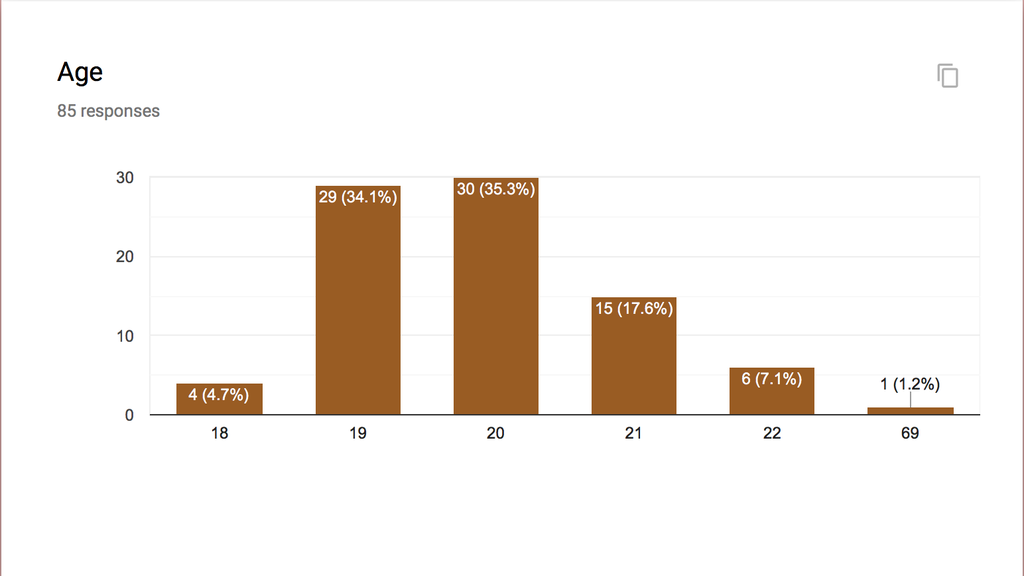

Breakdown by Age

```r
table(French_Fries_Responses_$AGE)
```

```
##
## 18 19 20 21 22 69
##  4 29 30 15  6  1
```

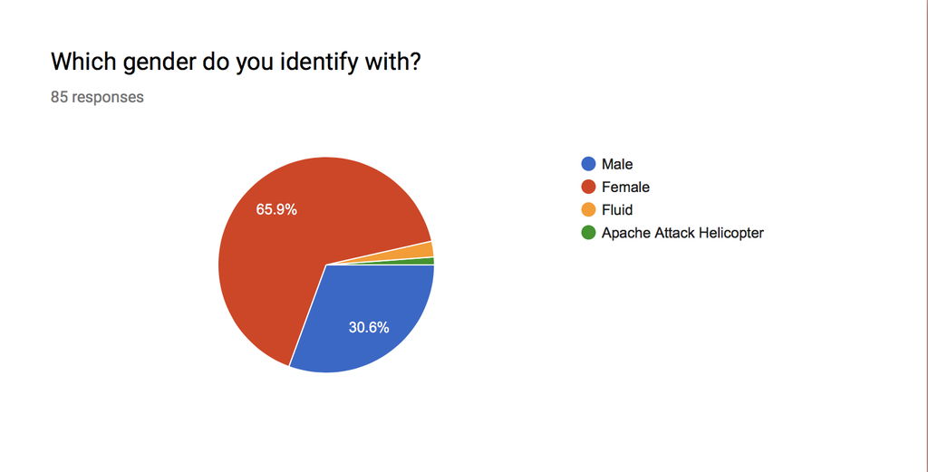

Breakdown by Gender

```r
table(French_Fries_Responses_$GENDER)
```

```
##
## Apache Attack Helicopter                   Female                    Fluid
##                        1                       56                        2
##                     Male
##                       26
```

*The “Apache Attack Helicopter” as a gender should be disregarded as inaccurate.*

### Mean Values

```r
# Find the mean value for each of the sauces
Mean_Ketchup <- mean(French_Fries_Responses_$Ketchup)
Mean_Mayonnaise <- mean(French_Fries_Responses_$Mayonnaise)
Mean_Ketcup_Mayonnaise <- mean(French_Fries_Responses_$`Ketchup mixed with mayonnaise`)
Mean_Mustard <- mean(French_Fries_Responses_$Mustard)
Mean_Mustard_Mayonnaise <- mean(French_Fries_Responses_$`Mustard mixed with mayonnaise`)
Mean_Ranch <- mean(French_Fries_Responses_$`Ranch dressing`)
Mean_Chocolate_Milkshake <- mean(French_Fries_Responses_$`Chocolate milkshake`)
Mean_Vanilla_Milkshake <- mean(French_Fries_Responses_$`Vanilla milkshake`)
Mean_Hot_Sauce <- mean(French_Fries_Responses_$`Hot sauce`)
Mean_Mayonnaise_Hot_Sauce <- mean(French_Fries_Responses_$`Mayonnaise and hot sauce`)
Mean_No_Sauce <- mean(French_Fries_Responses_$`No sauce`)
```

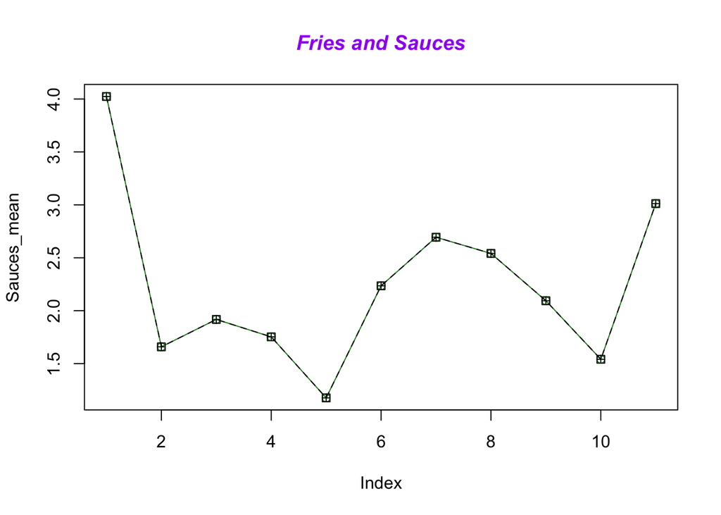

```r
#Create a set of means
Sauces_mean <- c(Mean_Ketchup, Mean_Mayonnaise, Mean_Ketcup_Mayonnaise, Mean_Mustard, Mean_Mustard_Mayonnaise, Mean_Ranch, Mean_Chocolate_Milkshake, Mean_Vanilla_Milkshake, Mean_Hot_Sauce, Mean_Mayonnaise_Hot_Sauce, Mean_No_Sauce)

#Associate numbers on the x-axis with the names of sauces
Sauces_numbers <- c("1", "2", "3", "4", "5", "6", "7", "8", "9", "10", "11")
names(Sauces_mean) <- Sauces_numbers

#Plot, with sauce numbers on the x-axis and means on the y-axis
plot(Sauces_mean, type="o", col="forestgreen")
lines(Sauces_mean, type="o", pch=12, lty=2, col="black")
title(main="Fries and Sauces", col.main="purple", font.main=4)
```

```r
#Show table with values for each mean

Sauces_names <- c("Ketchup", "Mayo", "Ketchup Mayo", "Mustard", "Mustard Mayo", "Ranch", "Choco Milk", "Vanilla Milk", "Hot Sauce", "Hot Sauce Mayo", "No Sauce")

fries_table <- matrix(c(Sauces_mean),ncol=1,byrow=TRUE)
  colnames(fries_table) <- c("Sauce Mean")
  rownames(fries_table) <- Sauces_names
  fries_table <- as.table(fries_table)
  fries_table
```

```
##                Sauce Mean
## Ketchup          4.023529
## Mayo             1.658824
## Ketchup Mayo     1.917647
## Mustard          1.752941
## Mustard Mayo     1.176471
## Ranch            2.235294
## Choco Milk       2.694118
## Vanilla Milk     2.541176
## Hot Sauce        2.094118
## Hot Sauce Mayo   1.541176
## No Sauce         3.011765
```

**Based on the graph and the table, it is clear that the highest mean value is 4.024 for ketchup, and the lowest mean value is 1.176, for the combination of mustard and mayonnaise.**

### Means grouped by gender

```r
#set up as data frame
French_Fries_Responses_df <- tbl_df(French_Fries_Responses_)
```

```r
#filter females from the data frame and find means
female_df <- filter(French_Fries_Responses_df, GENDER == "Female")
F_Ketchup <- mean(female_df$Ketchup)
F_Mayonnaise <- mean(female_df$Mayonnaise)
F_Ketcup_Mayonnaise <- mean(female_df$`Ketchup mixed with mayonnaise`)
F_Mustard <- mean(female_df$Mustard)
F_Mustard_Mayonnaise <- mean(female_df$`Mustard mixed with mayonnaise`)
F_Ranch <- mean(female_df$`Ranch dressing`)
F_Chocolate_Milkshake <- mean(female_df$`Chocolate milkshake`)
F_Vanilla_Milkshake <- mean(female_df$`Vanilla milkshake`)
F_Hot_Sauce <- mean(female_df$`Hot sauce`)
F_Mayonnaise_Hot_Sauce <- mean(female_df$`Mayonnaise and hot sauce`)
F_No_Sauce <- mean(female_df$`No sauce`)
```

```r
#filter males from data frame and find means
male_df <- filter(French_Fries_Responses_df, GENDER == "Male")
M_Ketchup <- mean(male_df$Ketchup)
M_Mayonnaise <- mean(male_df$Mayonnaise)
M_Ketcup_Mayonnaise <- mean(male_df$`Ketchup mixed with mayonnaise`)
M_Mustard <- mean(male_df$Mustard)
M_Mustard_Mayonnaise <- mean(male_df$`Mustard mixed with mayonnaise`)
M_Ranch <- mean(male_df$`Ranch dressing`)
M_Chocolate_Milkshake <- mean(male_df$`Chocolate milkshake`)
M_Vanilla_Milkshake <- mean(male_df$`Vanilla milkshake`)
M_Hot_Sauce <- mean(male_df$`Hot sauce`)
M_Mayonnaise_Hot_Sauce <- mean(male_df$`Mayonnaise and hot sauce`)
M_No_Sauce <- mean(male_df$`No sauce`)
```

```r
#set up for plots
Female_mean <- c(F_Ketchup, F_Mayonnaise, F_Ketcup_Mayonnaise, F_Mustard, F_Mustard_Mayonnaise, F_Ranch, F_Chocolate_Milkshake, F_Vanilla_Milkshake, F_Hot_Sauce, F_Mayonnaise_Hot_Sauce, F_No_Sauce)

Male_mean <- c(M_Ketchup, M_Mayonnaise, M_Ketcup_Mayonnaise, M_Mustard, M_Mustard_Mayonnaise, M_Ranch, M_Chocolate_Milkshake, M_Vanilla_Milkshake, M_Hot_Sauce, M_Mayonnaise_Hot_Sauce, M_No_Sauce)
```

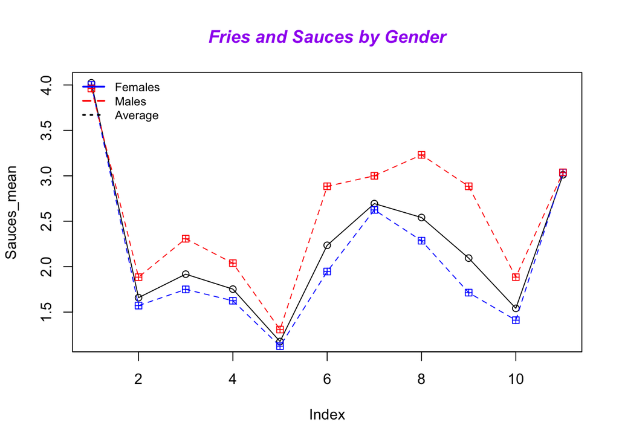

```r
#plot
plot(Sauces_mean, type="o", col="black")
lines(Female_mean, type="o", pch=12, lty=2, col="blue")
lines(Male_mean, type='o', pch=12, lty=2, col="red")
title(main="Fries and Sauces by Gender", col.main="purple", font.main=4)
plot_colors <- c("blue", "red", "black")
legend("topleft", c("Females", "Males", "Average"), cex=0.8, col=plot_colors,
   lty=1:3, lwd=2, bty="n")
```

```r
female_table <- matrix(c(Female_mean),ncol=1,byrow=TRUE)
  colnames(female_table) <- c("Female Mean")
  rownames(female_table) <- Sauces_names
  female_table <- as.table(female_table)
  female_table
```

```
##                Female Mean
## Ketchup           4.000000
## Mayo              1.571429
## Ketchup Mayo      1.750000
## Mustard           1.625000
## Mustard Mayo      1.125000
## Ranch             1.946429
## Choco Milk        2.625000
## Vanilla Milk      2.285714
## Hot Sauce         1.714286
## Hot Sauce Mayo    1.410714
## No Sauce          3.035714
```

```r
male_table <- matrix(c(Male_mean),ncol=1,byrow=TRUE)
  colnames(male_table) <- c("Male Mean")
  rownames(male_table) <- Sauces_names
  male_table <- as.table(male_table)
  male_table
```

```
##                Male Mean
## Ketchup         3.961538
## Mayo            1.884615
## Ketchup Mayo    2.307692
## Mustard         2.038462
## Mustard Mayo    1.307692
## Ranch           2.884615
## Choco Milk      3.000000
## Vanilla Milk    3.230769
## Hot Sauce       2.884615
## Hot Sauce Mayo  1.884615
## No Sauce        3.038462
```

**The tables and graph show us that in genereal, men are more tolerant of different sauces with fries than women are**

## Interpretation and limitations results

Based on the acquired data, men have higher means for every sauce except ketchup, which shows that they tend to expand their sauce options more than women do. Additionally, the mean values of the entire dataset show that ketchup is, indeed, still the most popular sauce for french fries. However, I can’t help but feel an overwhelming sense of dread at the number of positive responses for hot sauce and milkshakes. The alternative sauces for french fries might be expanding after all, and a longitudinal survey would portray whether there is an increasing trend over time between the responses.

One of the major limitiations of this survey is that it only collected data from a college student age group (with one exception). This means that the results cannot be generalized towards the whole US population or even all college students, since there might be regional variations. Another limitation is that some people requested that I add on other sauces, such as honey mustard, since they identified most strongly with those as their sauce of choice. For better results, I could have sent out a pre-survey screening asking people what sauces they would like to see on the survey.